# CRIM 545 Final Project: City of Fairfax Analysis

## Finding 3 – Monthly Forecast for 2026

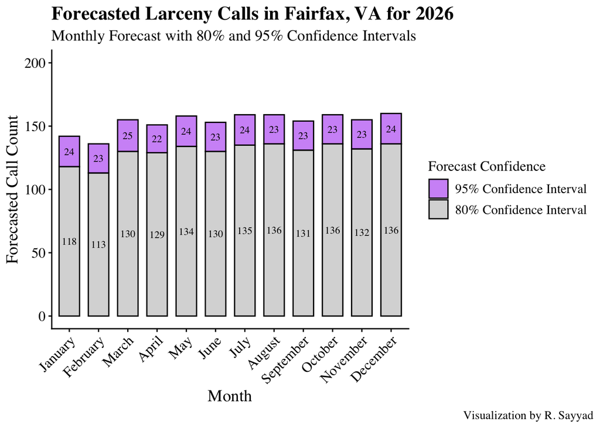

## Finding 4 – Weekday vs. Weekend Larceny Patterns by Location

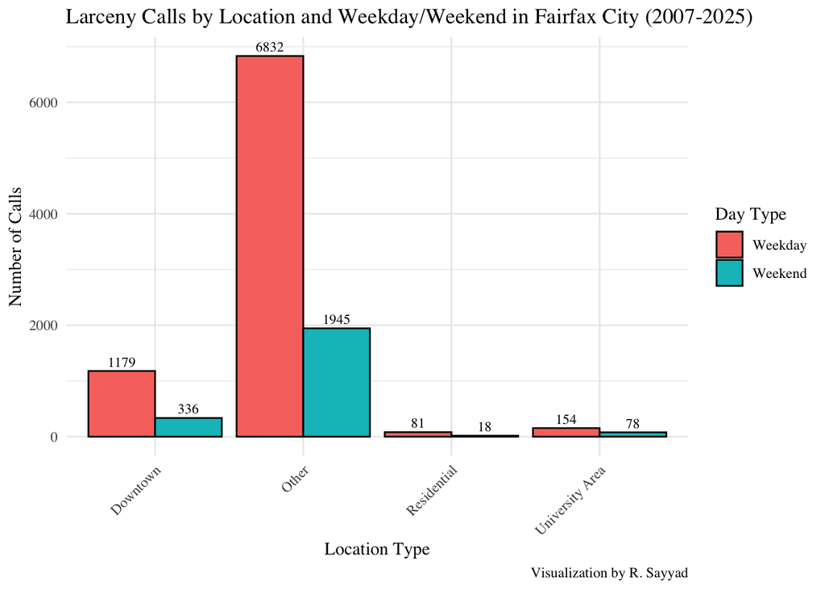

Larceny calls in Fairfax City from 2007 to 2025 show a striking pattern. Incidents are overwhelmingly concentrated on weekdays, particularly outside of downtown and university areas. “Other” locations account for the vast majority of calls, with 6,832 on weekdays compared to 1,945 on weekends, highlighting that larceny is strongly linked to routine weekday activity. Downtown Fairfax shows a similar trend, with 1,179 weekday calls versus only 336 on weekends. In contrast, the University Area displays a more balanced distribution, with 154 weekday calls and 78 on weekends. Residential areas consistently have the lowest volumes, particularly on weekends, with only 18 incidents, marking them as persistent cold spots. This distribution reveals a unique insight. Larceny risk is not evenly spread across the city or across time, but is concentrated in specific locations and heavily driven by weekday activity patterns. The results suggest that in 2026, these patterns are likely to continue, with non-residential, high-traffic areas during weekdays remaining the primary focus for prevention and monitoring.